# Analysis

Phillip Hungerford

27/03/2019

# Background

## DVH Metrics

- Bladder ~ V65Gy(%) stands for the relative volume of the bladder (as a percentage of the whole bladder volume) receiving 65Gy or more dose
- Bladder ~ D2cc(%) stands for minimum dose to the hottest 2cc i.e. cm^3 of bladder subvolume expressed as a percentage of the prescription dose (Drx)
- any such metrics can be read off the cumulative DVH curve of a particular organ (see also this post for more info on this: http://www.carlosjanderson.com/understanding-the-meaning-of-dvh-metrics/)

# Data exploration and analysis

Load the data

```r
mydata <- read.csv("../../2_pipeline/labels_n.csv")
```

Exploration

```r
head(mydata)
```

```
##   Bladder_ANY Bladder_num Rectum_ANY Bladder_num2 Bla_Rec_ANY
## 1           1           1         NA            0           1
## 2           1           1         NA            0           1
## 3          NA           0         NA            0          NA
## 4          NA           0         NA            0          NA
## 5          NA           0         NA            0          NA
## 6          NA           0         NA            0          NA
##                 Group   ID Drx Bladder_Vol Bladder_D2cc_percent
## 1 2. pro def with LNs 1358  80       340.1             103.5794
## 2 2. pro def with LNs 1434  80       164.0             103.3126
## 3 1. pro def no nodes 1455  80       146.8             103.9256
## 4 1. pro def no nodes 1567  80       244.7             103.9878
## 5 1. pro def no nodes 1571  80       269.2             103.7485
## 6 1. pro def no nodes 1581  80       293.9             102.8973
##   Bladder_D2cc_violation Bladder_D2cc Bladder_V40Gy_percent
```

[output cut: 48 more lines]

```r
str(mydata)
```

```
## 'data.frame':    417 obs. of  28 variables:
##  $ Bladder_ANY                : int  1 1 NA NA NA NA NA NA NA NA ...
##  $ Bladder_num                : int  1 1 0 0 0 0 0 0 0 0 ...
##  $ Rectum_ANY                 : int  NA NA NA NA NA NA 1 1 NA NA ...
##  $ Bladder_num2               : int  0 0 0 0 0 0 1 1 0 0 ...
##  $ Bla_Rec_ANY                : int  1 1 NA NA NA NA 1 1 NA NA ...
##  $ Group                      : Factor w/ 3 levels "","1. pro def no nodes",..: 3 3 2 2 2 2 3 3 2 3 ...
##  $ ID                         : int  1358 1434 1455 1567 1571 1581 1588 1599 1600 1627 ...
##  $ Drx                        : num  80 80 80 80 80 80 80 80 80 80 ...
##  $ Bladder_Vol                : num  340 164 147 245 269 ...
##  $ Bladder_D2cc_percent       : num  104 103 104 104 104 ...
##  $ Bladder_D2cc_violation     : int  NA NA NA NA NA NA NA NA NA NA ...
##  $ Bladder_D2cc               : num  82.9 82.7 83.1 83.2 83 ...
##  $ Bladder_V40Gy_percent      : num  56.1 53.3 25.4 27.6 47.5 ...
##  $ Bladder_V40_violation      : int  1 1 NA NA NA NA NA NA NA NA ...
##  $ Bladder_V65Gy_percent      : num  18.2 14.1 11.5 11.7 23.2 ...
##  $ Bladder_V65_violation      : int  NA NA NA NA NA NA NA NA NA NA ...
##  $ PTVHD_Vol                  : num  147.4 76.3 96.8 181.4 209.9 ...
##  $ PTVHD_D95                  : num  100 100 101 100 100 ...
##  $ Rectum_Vol                 : num  64.6 69.8 51.8 91.4 81 78.4 51.3 89.3 82.5 99 ...
##  $ Rectum_D2cc_percent        : num  102.2 88.4 98.2 97.1 100.3 ...
##  $ Rectum_D2cc_MINOR_violation: int  NA NA NA NA NA NA NA NA NA NA ...
##  $ Rectum_D2cc_MAJOR_violation: logi  NA NA NA NA NA NA ...
##  $ Rectum_V40Gy_percent       : num  34.3 33.5 24.7 25.6 34.9 ...
##  $ Rectum_V40_MINOR_violation : int  NA NA NA NA NA NA 1 NA NA NA ...
##  $ Rectum_V40_MAJOR_violation : int  NA NA NA NA NA NA NA NA NA NA ...
##  $ Rectum_V65Gy_percent       : num  16.8 5.79 9.29 7.14 15.47 ...
##  $ Rectum_V65_MINOR_violation : int  NA NA NA NA NA NA NA 1 NA NA ...
##  $ Rectum_V65_MAJOR_violation : int  NA NA NA NA NA NA NA NA NA NA ...
```

As we can see we have categorical and numeric variables so we will turn the NA values to ‘0’.

```r
mydata[is.na(mydata)] <- 0
#sanity check
head(mydata)
```

```
##   Bladder_ANY Bladder_num Rectum_ANY Bladder_num2 Bla_Rec_ANY
## 1           1           1          0            0           1
## 2           1           1          0            0           1
## 3           0           0          0            0           0
## 4           0           0          0            0           0
## 5           0           0          0            0           0
## 6           0           0          0            0           0
##                 Group   ID Drx Bladder_Vol Bladder_D2cc_percent
## 1 2. pro def with LNs 1358  80       340.1             103.5794
## 2 2. pro def with LNs 1434  80       164.0             103.3126
## 3 1. pro def no nodes 1455  80       146.8             103.9256
## 4 1. pro def no nodes 1567  80       244.7             103.9878
## 5 1. pro def no nodes 1571  80       269.2             103.7485
## 6 1. pro def no nodes 1581  80       293.9             102.8973
##   Bladder_D2cc_violation Bladder_D2cc Bladder_V40Gy_percent
```

[output cut: 48 more lines]

```r
summary(mydata)
```

```
##   Bladder_ANY      Bladder_num       Rectum_ANY      Bladder_num2
##  Min.   :0.0000   Min.   :0.0000   Min.   :0.0000   Min.   :0.0000
##  1st Qu.:0.0000   1st Qu.:0.0000   1st Qu.:0.0000   1st Qu.:0.0000
##  Median :0.0000   Median :0.0000   Median :0.0000   Median :0.0000
##  Mean   :0.1799   Mean   :0.2254   Mean   :0.2734   Mean   :0.3669
##  3rd Qu.:0.0000   3rd Qu.:0.0000   3rd Qu.:1.0000   3rd Qu.:1.0000
##  Max.   :1.0000   Max.   :2.0000   Max.   :1.0000   Max.   :3.0000
##   Bla_Rec_ANY                     Group           ID            Drx
##  Min.   :0.0000                      :  1   Min.   :   0   Min.   : 0.00
##  1st Qu.:0.0000   1. pro def no nodes:286   1st Qu.:3717   1st Qu.:80.00
##  Median :0.0000   2. pro def with LNs:130   Median :4950   Median :80.00
##  Mean   :0.3813                             Mean   :4887   Mean   :80.96
##  3rd Qu.:1.0000                             3rd Qu.:6204   3rd Qu.:82.80
##  Max.   :1.0000                             Max.   :7925   Max.   :85.20
##   Bladder_Vol    Bladder_D2cc_percent Bladder_D2cc_violation
##  Min.   :  0.0   Min.   :  0.0        Min.   :0.000000
##  1st Qu.:196.4   1st Qu.:100.6        1st Qu.:0.000000
##  Median :268.7   Median :102.5        Median :0.000000
##  Mean   :291.8   Mean   :101.7        Mean   :0.002398
##  3rd Qu.:361.5   3rd Qu.:103.4        3rd Qu.:0.000000
##  Max.   :860.3   Max.   :105.2        Max.   :1.000000
##   Bladder_D2cc   Bladder_V40Gy_percent Bladder_V40_violation
##  Min.   : 0.00   Min.   : 0.00         Min.   :0.0000
##  1st Qu.:82.16   1st Qu.:19.95         1st Qu.:0.0000
##  Median :82.72   Median :28.51         Median :0.0000
##  Mean   :82.50   Mean   :33.31         Mean   :0.1583
##  3rd Qu.:83.29   3rd Qu.:47.20         3rd Qu.:0.0000
##  Max.   :87.05   Max.   :84.11         Max.   :1.0000
##  Bladder_V65Gy_percent Bladder_V65_violation   PTVHD_Vol
##  Min.   : 0.00         Min.   :0.00000       Min.   :  0.0
##  1st Qu.: 7.98         1st Qu.:0.00000       1st Qu.:108.7
##  Median :11.27         Median :0.00000       Median :133.0
##  Mean   :13.09         Mean   :0.06475       Mean   :142.8
##  3rd Qu.:16.60         3rd Qu.:0.00000       3rd Qu.:164.4
##  Max.   :44.11         Max.   :1.00000       Max.   :477.3
##    PTVHD_D95        Rectum_Vol     Rectum_D2cc_percent
##  Min.   :  0.00   Min.   :  0.00   Min.   :  0.00
##  1st Qu.: 96.28   1st Qu.: 55.20   1st Qu.: 96.72
##  Median :100.00   Median : 65.10   Median : 98.67
##  Mean   : 98.10   Mean   : 69.56   Mean   : 97.30
```

[output cut: 15 more lines]

```
##  Max.   :43.76        Max.   :1.0000
##  Rectum_V40_MAJOR_violation Rectum_V65Gy_percent
##  Min.   :0.00000            Min.   : 0.00
##  1st Qu.:0.00000            1st Qu.:10.05
##  Median :0.00000            Median :14.05
##  Mean   :0.01439            Mean   :13.06
##  3rd Qu.:0.00000            3rd Qu.:16.45
##  Max.   :1.00000            Max.   :23.77
##  Rectum_V65_MINOR_violation Rectum_V65_MAJOR_violation
##  Min.   :0.0000             Min.   :0.00000
##  1st Qu.:0.0000             1st Qu.:0.00000
##  Median :0.0000             Median :0.00000
##  Mean   :0.1751             Mean   :0.01439
##  3rd Qu.:0.0000             3rd Qu.:0.00000
##  Max.   :1.0000             Max.   :1.00000
```

## Correlation matrix

```r
# Create a correlation matrix
mydata.cor <- cor(mydata[sapply(mydata, is.numeric)], method=c('spearman'))
```

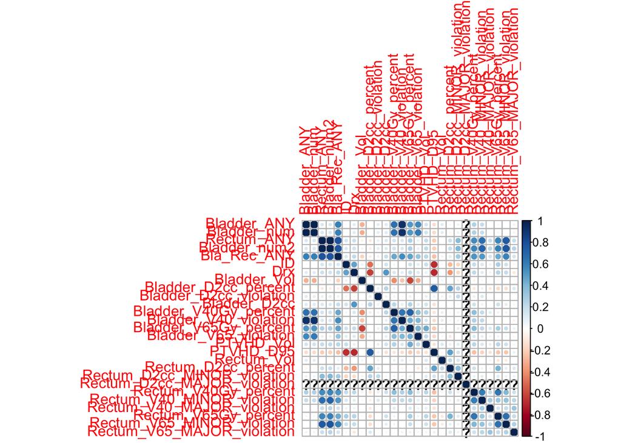

```r
# install package if needed
#install.packages("corrplot")

#load package
library("corrplot")
# visualise correlations
corrplot(mydata.cor)
```

```r
round(mydata.cor, 2)
```

```
##                             Bladder_ANY Bladder_num Rectum_ANY
## Bladder_ANY                        1.00        1.00       0.13
## Bladder_num                        1.00        1.00       0.14
## Rectum_ANY                         0.13        0.14       1.00
## Bladder_num2                       0.13        0.14       0.99
## Bla_Rec_ANY                        0.60        0.59       0.78
## ID                                 0.02        0.03       0.15
## Drx                                0.10        0.11       0.18
## Bladder_Vol                       -0.31       -0.32      -0.06
## Bladder_D2cc_percent               0.00       -0.01      -0.09
## Bladder_D2cc_violation             0.10        0.10       0.08
## Bladder_D2cc                       0.11        0.12       0.13
## Bladder_V40Gy_percent              0.65        0.65       0.16
## Bladder_V40_violation              0.93        0.93       0.13
## Bladder_V65Gy_percent              0.51        0.52       0.26
## Bladder_V65_violation              0.56        0.62       0.08
## PTVHD_Vol                          0.16        0.17       0.20
## PTVHD_D95                         -0.16       -0.17      -0.21
## Rectum_Vol                         0.10        0.10      -0.01
## Rectum_D2cc_percent               -0.03       -0.04       0.18
## Rectum_D2cc_MINOR_violation        0.06        0.06       0.38
## Rectum_D2cc_MAJOR_violation          NA          NA         NA
## Rectum_V40Gy_percent               0.26        0.26       0.55
## Rectum_V40_MINOR_violation         0.20        0.21       0.66
## Rectum_V40_MAJOR_violation         0.00        0.00       0.20
## Rectum_V65Gy_percent               0.03        0.03       0.58
## Rectum_V65_MINOR_violation         0.00        0.00       0.75
## Rectum_V65_MAJOR_violation        -0.06       -0.06       0.20
##                             Bladder_num2 Bla_Rec_ANY    ID   Drx
## Bladder_ANY                         0.13        0.60  0.02  0.10
## Bladder_num                         0.14        0.59  0.03  0.11
## Rectum_ANY                          0.99        0.78  0.15  0.18
## Bladder_num2                        1.00        0.77  0.14  0.16
## Bla_Rec_ANY                         0.77        1.00  0.13  0.22
## ID                                  0.14        0.13  1.00  0.47
## Drx                                 0.16        0.22  0.47  1.00
## Bladder_Vol                        -0.05       -0.19  0.07  0.02
## Bladder_D2cc_percent               -0.08       -0.07 -0.50 -0.62
## Bladder_D2cc_violation              0.10        0.06 -0.04 -0.03
## Bladder_D2cc                        0.12        0.19  0.17  0.51
```

[output cut: 393 more lines]

```
## Bladder_V40_violation                            -0.05
## Bladder_V65Gy_percent                             0.07
## Bladder_V65_violation                            -0.03
## PTVHD_Vol                                         0.05
## PTVHD_D95                                         0.07
## Rectum_Vol                                       -0.01
## Rectum_D2cc_percent                               0.12
## Rectum_D2cc_MINOR_violation                       0.06
## Rectum_D2cc_MAJOR_violation                         NA
## Rectum_V40Gy_percent                              0.18
## Rectum_V40_MINOR_violation                        0.24
## Rectum_V40_MAJOR_violation                        0.32
## Rectum_V65Gy_percent                              0.21
## Rectum_V65_MINOR_violation                        0.26
## Rectum_V65_MAJOR_violation                        1.00
```

# Violations

So we want to predict bladder and rectum violations as per the initial study.

## Any violation

Check the number of violations in the dataset.

```r
sum(mydata$Bla_Rec_ANY)
```

```
## [1] 159
```

We can see that out of the 417 patients, 159 in total have a plan violation. We can run a multi-variate linear regression model to find significant predictors of a violation.

```r
# Run MVLR model on all predictors
any_model <- lm(Bla_Rec_ANY ~ Bladder_D2cc_percent + Bladder_V40Gy_percent + Bladder_V65Gy_percent + Rectum_D2cc_percent + Rectum_V40Gy_percent + Rectum_V65Gy_percent, data=mydata)
summary(any_model)
```

```
##
## Call:
## lm(formula = Bla_Rec_ANY ~ Bladder_D2cc_percent + Bladder_V40Gy_percent +
##     Bladder_V65Gy_percent + Rectum_D2cc_percent + Rectum_V40Gy_percent +
##     Rectum_V65Gy_percent, data = mydata)
##
## Residuals:
##      Min       1Q   Median       3Q      Max
## -0.74739 -0.28262 -0.06389  0.29368  1.02542
##
## Coefficients:
##                        Estimate Std. Error t value Pr(>|t|)
## (Intercept)            0.027936   0.355655   0.079  0.93743
## Bladder_D2cc_percent   0.004453   0.005642   0.789  0.43043
## Bladder_V40Gy_percent  0.008115   0.001788   4.540 7.42e-06 ***
## Bladder_V65Gy_percent  0.011075   0.004017   2.757  0.00609 **
## Rectum_D2cc_percent   -0.015265   0.004842  -3.153  0.00174 **
## Rectum_V40Gy_percent   0.013465   0.005803   2.320  0.02081 *
## Rectum_V65Gy_percent   0.042276   0.007922   5.337 1.57e-07 ***
## ---
## Signif. codes:  0 '***' 0.001 '**' 0.01 '*' 0.05 '.' 0.1 ' ' 1
##
## Residual standard error: 0.3771 on 410 degrees of freedom
## Multiple R-squared:  0.4074, Adjusted R-squared:  0.3988
## F-statistic: 46.98 on 6 and 410 DF,  p-value: < 2.2e-16
```

## Bladder

In the Caine et al paper a bladder violation was defined if any of the following threshold was breached (i.e. any of the following conditions became true):

- Bladder ~ D2cc(%) >= 105%
- Bladder ~ V40Gy(%) >= 50%
- Bladder ~ V65Gy(%) >= 25%

For the bladder, dosimetric outcome measures included the 1-cm3 maximum dose, V40 Gy, and V65 Gy, which were correlated with bladder volume, OB (cm3), OB (%), volume of prostate (cm3), Hydrogel (yes or no), and lymph node treatment (yes or no).

```r
#bladder_violation <- lm(Bladder_ANY ~ Bladder_D2cc_percent + Bladder_V40Gy_percent + Bladder_V65Gy_percent, data=mydata)
#summary(bladder_violation)
```

## Rectum

In the Caine et al paper a rectum violation was defined if any of the following threshold was breached (i.e. any of the following conditions became true):

- Rectum ~ D2cc(%) >= 102.5%
- Rectum ~ V40Gy(%) >= 35%
- Rectum ~ V65Gy(%) >=17%

For the rectum, dosimetric outcome measures included the 1-cm3 maximum dose, V40 Gy, and V65 Gy, which were correlated with rectal volume, OR (cm3), OR (%), volume of prostate (cm3), Hydrogel (yes or no), and lymph node treatment (yes or no).

```r
#rectum_violation <- lm(Rectum_ANY ~ Bladder_D2cc_percent + Bladder_V40Gy_percent + Bladder_V65Gy_percent, data=mydata)
#summary(rectum_violation)
```